# Sampling distributions: live R demonstrations

POLI 210 - October 7, 2026

Author

Brad LeVeck

## Using this document

Open this QMD in RStudio and run a numbered chunk with its green arrow. **Each numbered chunk defines its own inputs and can run in a fresh R session.** There are no downloads, external data files, or helper scripts to source. The calculations use base R. Rendering uses knitr and rmarkdown.

All populations and numerical examples are hypothetical. In repeated-sample examples, `n` is the number of observations in each sample and `B` is the number of independently generated samples. The HTML is a saved reference.

For class, prioritize Demos 2-3, 6-8 (including 8b), and 11. The other sections support questions or practice. The two final demos are optional previews.

## 1. Brief reminder: one PMF and one event

Suppose four people independently favor a proposal with probability 0.6. Let $K$ count the supporters.

**Predict:** Will increasing the number of simulations change the true distribution of $K$?

```r
set.seed(100701)
B <- 10000
supporters <- rbinom(B, size = 4, prob = .6)
values <- 0:4
estimated_pmf <- as.numeric(table(factor(supporters, levels = values))) / B
comparison <- data.frame(value = values,
                         estimated = estimated_pmf,
                         exact = dbinom(values, 4, .6))
print(comparison)
```

```
  value estimated  exact
1     0    0.0243 0.0256
2     1    0.1572 0.1536
3     2    0.3487 0.3456
4     3    0.3440 0.3456
5     4    0.1258 0.1296
```

```r
print(c(simulated_event = mean(supporters >= 3),
        exact_event = 1 - pbinom(2, 4, .6)))
```

```
simulated_event     exact_event
         0.4698          0.4752
```

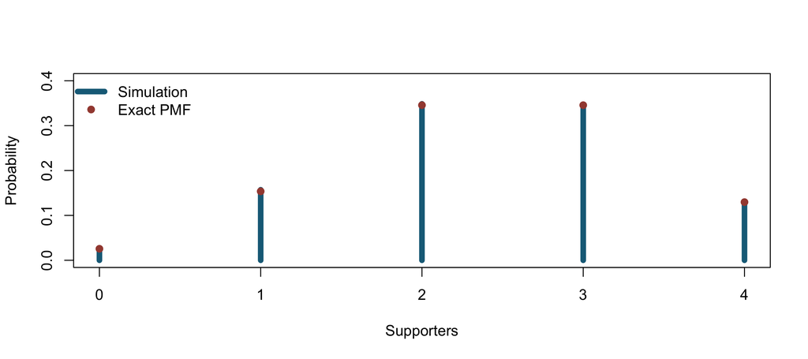

```r
plot(values, estimated_pmf, type = "h", lwd = 6, col = "#176B87",
     xlab = "Supporters", ylab = "Probability", ylim = c(0, .4), xaxt = "n")
axis(1, at = values)
points(values, comparison$exact, pch = 19, col = "#A44A3F")
legend("topleft", c("Simulation", "Exact PMF"), col = c("#176B87", "#A44A3F"),
       lwd = c(6, NA), pch = c(NA, 19), bty = "n")
```

Try `B <- 100`, then rerun the **whole chunk**. The estimate gets noisier. Zero occurrences in a simulation need not mean an impossible outcome.

## 2. Histogram area and a known density

Let $V\sim\operatorname{Norm}(3,5)$ be a hypothetical margin in percentage points. The second parameter is the standard deviation.

**Predict:** Why must the histogram use `probability = TRUE` before we add `dnorm()`?

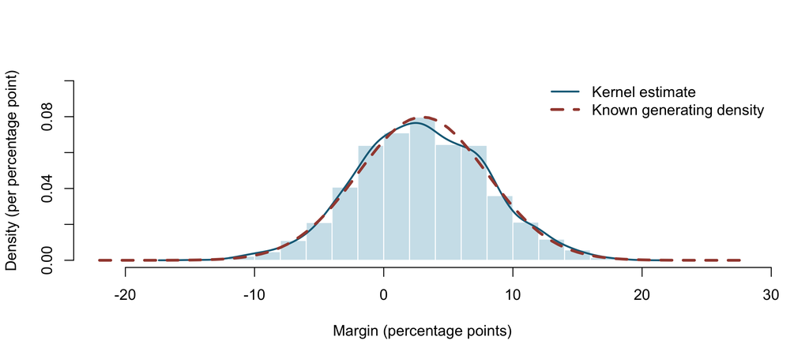

```r
set.seed(100702)
B <- 2000
draws <- rnorm(B, mean = 3, sd = 5)
# A density histogram has total bar area one.
histogram <- hist(draws, breaks = seq(-22, 28, by = 2),
                  probability = TRUE, col = "#CEE3EB", border = "white",
                  main = "", xlab = "Margin (percentage points)",
                  ylab = "Density (per percentage point)", ylim = c(0, .10))
lines(density(draws), col = "#176B87", lwd = 2)
# curve() supplies evaluation locations named x.
curve(dnorm(x, mean = 3, sd = 5), add = TRUE, col = "#A44A3F", lwd = 3, lty = 2)
legend("topright", c("Kernel estimate", "Known generating density"),
       col = c("#176B87", "#A44A3F"), lwd = c(2, 3), lty = c(1, 2), bty = "n")
```

```r
print(sum(histogram$density * diff(histogram$breaks)))
```

```
[1] 1
```

```r
j <- which(head(histogram$breaks, -1) == 2)
print(data.frame(bin_left = 2, bin_right = 4,
                 fraction = histogram$counts[j] / B,
                 height = histogram$density[j],
                 width = 2, area = histogram$density[j] * 2))
```

```
  bin_left bin_right fraction  height width   area
1        2         4   0.1595 0.07975     2 0.1595
```

```r
print(c(simulated_interval = mean(draws > 2 & draws <= 4),
        exact_interval = pnorm(4, 3, 5) - pnorm(2, 3, 5)))
```

```
simulated_interval     exact_interval
         0.1595000          0.1585194
```

The blue and red curves have density units, like the bar heights. Their areas over intervals correspond to probabilities. The generating parameters are known because we chose the simulation model.

## 3. Kernel smoothing by adding small bumps

Use five observed values so every contribution is visible. For a Gaussian kernel with bandwidth $h$, the contribution of observation $x_b$ at location $x$ is `dnorm(x, mean = x_b, sd = h) / B`.

**Predict:** Why divide each bump by the number of observations?

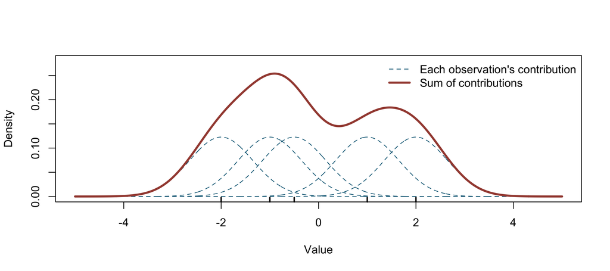

```r
observations <- c(-2, -1, -.5, 1, 2)
B <- length(observations)
h <- .65
grid <- seq(-5, 5, length.out = 1501)
bumps <- matrix(0, nrow = length(grid), ncol = B)
for (b in seq_along(observations)) {
  bumps[, b] <- dnorm(grid, mean = observations[b], sd = h) / B
}
manual_density <- rowSums(bumps)
matplot(grid, bumps, type = "l", col = "#176B87", lty = 2, lwd = 1,
        ylim = c(0, .28), xlab = "Value", ylab = "Density")
lines(grid, manual_density, col = "#A44A3F", lwd = 3)
rug(observations, lwd = 2)
legend("topright", c("Each observation's contribution", "Sum of contributions"),
       col = c("#176B87", "#A44A3F"), lty = c(2, 1), lwd = c(1, 3), bty = "n")
```

```r
# Compare the direct formula with R's grid-based numerical implementation.
fit <- density(observations, bw = h, from = -5, to = 5, n = 2048)
direct_at_r_grid <- sapply(fit$x, function(location) {
  mean(dnorm(location, mean = observations, sd = h))
})
print(c(max_grid_difference = max(abs(fit$y - direct_at_r_grid)),
        approximate_area = sum(diff(grid) *
          (head(manual_density, -1) + tail(manual_density, -1)) / 2)))
```

```
max_grid_difference    approximate_area
       3.099656e-06        9.999992e-01
```

```r
# Height near zero times a narrow width approximates probability near zero.
epsilon <- .05
height_at_zero <- mean(dnorm(0, observations, h))
interval_area <- mean(pnorm(epsilon, observations, h) -
                      pnorm(-epsilon, observations, h))
print(c(density_at_zero = height_at_zero,
        width_times_height = 2 * epsilon * height_at_zero,
        exact_area_under_kernel_mixture = interval_area))
```

```
                density_at_zero              width_times_height
                     0.16865221                      0.01686522
exact_area_under_kernel_mixture
                     0.01687347
```

The interval calculation describes the **estimated kernel mixture**, not a known population probability. The mixture spreads area around observations. It does not assume that each observed value is a noisy measurement of a hidden Normal value.

`density()` uses grid approximations for speed, so numerical equality with the direct formula is not exact. No need to study that implementation in class.

## 4. Bandwidth and boundaries

The next plot uses the same data three times. Only the bandwidth changes.

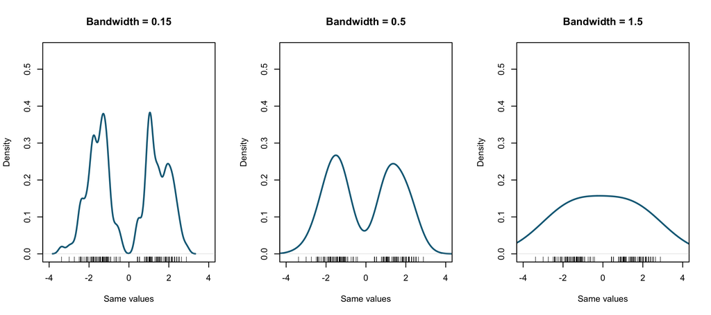

```r
set.seed(100703)
observations <- c(rnorm(70, -1.5, .6), rnorm(70, 1.5, .6))
old_par <- par(no.readonly = TRUE)
par(mfrow = c(1, 3))
for (h in c(.15, .5, 1.5)) {
  plot(density(observations, bw = h), main = paste("Bandwidth =", h),
       col = "#176B87", lwd = 2, xlim = c(-4, 4), ylim = c(0, .55),
       xlab = "Same values", ylab = "Density")
  rug(observations)
}
```

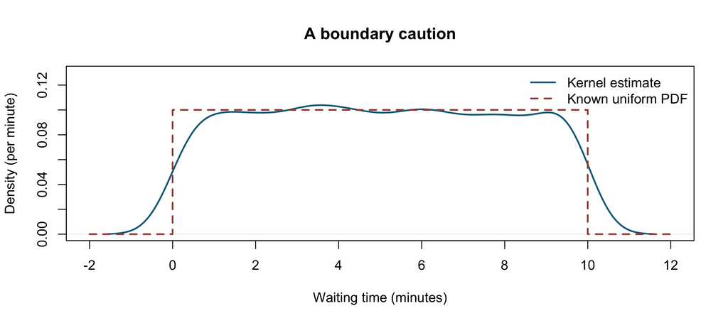

```r
par(old_par)

set.seed(100704)
waits <- runif(3000, 0, 10)
plot(density(waits), col = "#176B87", lwd = 2, main = "A boundary caution",
     xlim = c(-2, 12), ylim = c(0, .13),
     xlab = "Waiting time (minutes)", ylab = "Density (per minute)")
lines(c(-2, 0, 0, 10, 10, 12), c(0, 0, .1, .1, 0, 0),
      col = "#A44A3F", lwd = 2, lty = 2)
legend("topright", c("Kernel estimate", "Known uniform PDF"),
       col = c("#176B87", "#A44A3F"), lwd = 2, lty = c(1, 2), bty = "n")
```

Gaussian bumps can create several peaks. They can also put area outside the possible range. That area is a smoothing artifact in this example. Changing the plot limits hides it but does not correct the estimate.

## 5. Known parameters and a fitted comparison

Here we know the mean and SD of a transformed Normal variable. We can compare that curve with one using simulated sample moments.

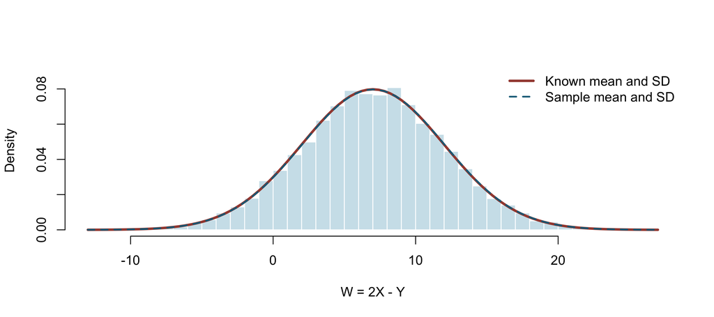

```r
set.seed(100705)
B <- 20000
X <- rnorm(B, mean = 4, sd = 2)
Y <- rnorm(B, mean = 1, sd = 3)  # independent of X
W <- 2 * X - Y
mu_w <- 2 * 4 - 1
sigma_w <- sqrt(2^2 * 2^2 + (-1)^2 * 3^2)
mu_hat <- mean(W)
sigma_hat <- sd(W)
hist(W, breaks = 45, probability = TRUE, col = "#CEE3EB", border = "white",
     main = "", xlab = "W = 2X - Y", ylab = "Density", ylim = c(0, .09))
curve(dnorm(x, mu_w, sigma_w), add = TRUE, col = "#A44A3F", lwd = 3)
curve(dnorm(x, mu_hat, sigma_hat), add = TRUE, col = "#176B87", lwd = 2, lty = 2)
legend("topright", c("Known mean and SD", "Sample mean and SD"),
       col = c("#A44A3F", "#176B87"), lwd = c(3, 2), lty = c(1, 2), bty = "n")
```

```r
print(data.frame(quantity = c("Mean", "SD"),
                 known = c(mu_w, sigma_w), fitted = c(mu_hat, sigma_hat)))
```

```
  quantity known   fitted
1     Mean     7 7.030155
2       SD     5 5.005611
```

Independence lets us add variances. Coefficients are squared in that calculation. The SD is the square root of the resulting variance. These sample-moment choices are sensible for a Normal comparison; later we will study what makes an estimator good and methods such as maximum likelihood. There is no universally best fitting method for every model.

## 6. One observation, one sample, many samples

Return to the hypothetical debate audience: 60% favor A, 30% favor B, and 10% are unsure.

```r
set.seed(100706)
categories <- c("A", "B", "Unsure")
population_probabilities <- c(.6, .3, .1)
n <- 100
B <- 20000
one_sample <- sample(categories, size = n, replace = TRUE,
                     prob = population_probabilities)
print(table(factor(one_sample, levels = categories)))
```

```
     A      B Unsure
    60     30     10
```

```r
print(mean(one_sample == "A"))
```

```
[1] 0.6
```

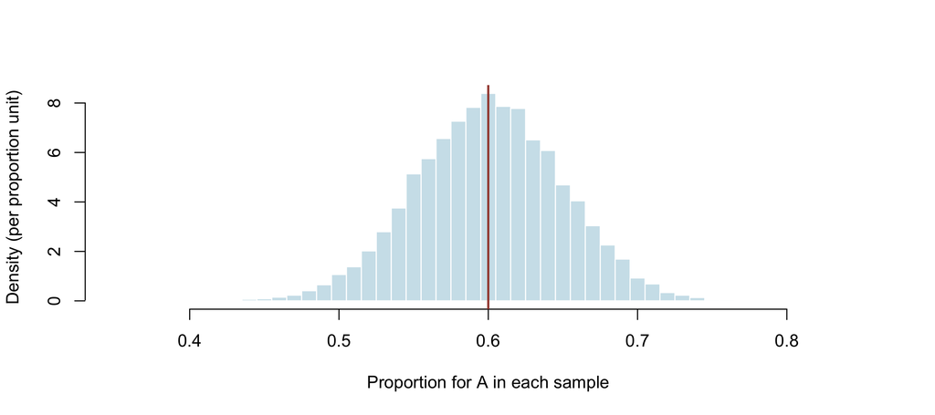

```r
sample_proportions <- replicate(B, {
  people <- sample(categories, size = n, replace = TRUE,
                   prob = population_probabilities)
  mean(people == "A")
})
hist(sample_proportions, breaks = seq(-.005, 1.005, by = .01),
     probability = TRUE, col = "#CEE3EB", border = "white", main = "",
     xlim = c(.35, .85), xlab = "Proportion for A in each sample",
     ylab = "Density (per proportion unit)")
abline(v = .6, col = "#A44A3F", lwd = 2)
```

```r
print(data.frame(quantity = c("Mean of proportions", "Variance of proportions",
                             "SD of proportions"),
                 theoretical = c(.6, .6 * .4 / n, sqrt(.6 * .4 / n)),
                 simulated = c(mean(sample_proportions),
                               var(sample_proportions), sd(sample_proportions))))
```

```
                 quantity theoretical   simulated
1     Mean of proportions  0.60000000 0.600373500
2 Variance of proportions  0.00240000 0.002410956
3       SD of proportions  0.04898979 0.049101487
```

```r
# Shorter, equivalent generation of counts, then division by n:
shortcut <- rbinom(B, size = n, prob = .6) / n
print(c(full_experiment = sd(sample_proportions), shortcut = sd(shortcut)))
```

```
full_experiment        shortcut
     0.04910149      0.04868091
```

The two simulations need not give identical numbers. They target the same distribution. The count is exactly binomial; the proportion is that count divided by `n`. Its possible values remain discrete even if a histogram looks smooth.

## 7. Sample size versus simulation replications

**Predict:** Which comparison changes the true spread?

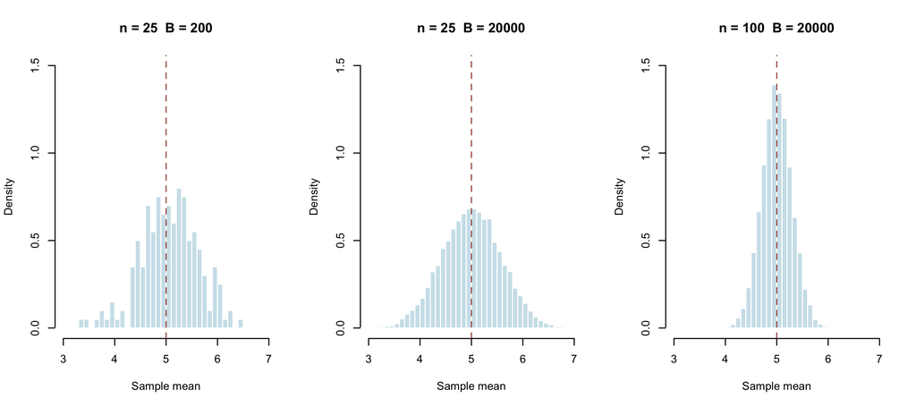

```r
set.seed(100708)
settings <- data.frame(n = c(25, 25, 100), B = c(200, 20000, 20000))
results <- settings
results$simulated_sd <- NA_real_
results$theoretical_se <- NA_real_
old_par <- par(no.readonly = TRUE)
par(mfrow = c(1, 3))
for (j in seq_len(nrow(settings))) {
  n <- settings$n[j]
  B <- settings$B[j]
  sample_means <- replicate(B, mean(runif(n, min = 0, max = 10)))
  results$simulated_sd[j] <- sd(sample_means)
  results$theoretical_se[j] <- (10 / sqrt(12)) / sqrt(n)
  hist(sample_means, breaks = seq(0, 10, by = .1), probability = TRUE,
       xlim = c(3, 7), ylim = c(0, 1.5), col = "#CEE3EB", border = "white",
       main = paste("n =", n, " B =", B), xlab = "Sample mean", ylab = "Density")
  abline(v = 5, col = "#A44A3F", lty = 2)
}
```

```r
par(old_par)
print(results)
```

```
    n     B simulated_sd theoretical_se
1  25   200    0.5586479      0.5773503
2  25 20000    0.5784499      0.5773503
3 100 20000    0.2912381      0.2886751
```

More replications make the estimated distribution less noisy. Larger samples make the distribution of the mean narrower. The uniform population itself retains variance $100/12$.

## 8. LLN paths and CLT shapes

First, watch several running averages. Then center and scale repeated sample means to compare their shapes.

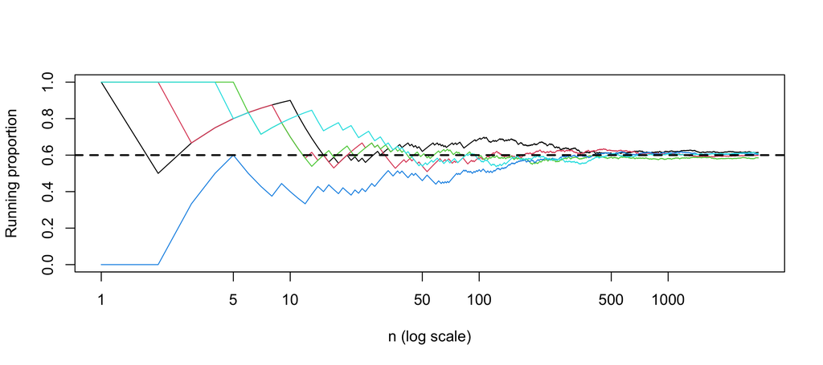

```r
set.seed(100709)
n_max <- 3000
paths <- replicate(5, cumsum(rbinom(n_max, 1, .6)) / seq_len(n_max))
matplot(seq_len(n_max), paths, type = "l", lty = 1, log = "x",
        ylim = c(0, 1), xlab = "n (log scale)", ylab = "Running proportion")
abline(h = .6, lty = 2, lwd = 2)
```

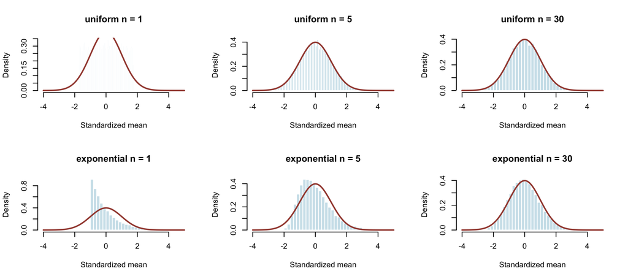

```r
set.seed(100711)
B <- 15000
old_par <- par(no.readonly = TRUE)
par(mfrow = c(2, 3))
for (family in c("uniform", "exponential")) {
  for (n in c(1, 5, 30)) {
    if (family == "uniform") {
      sample_means <- replicate(B, mean(runif(n, 0, 10)))
      mu <- 5
      sigma <- 10 / sqrt(12)
    } else {
      sample_means <- replicate(B, mean(rexp(n, rate = .2)))
      mu <- 5
      sigma <- 5
    }
    z_means <- (sample_means - mu) / (sigma / sqrt(n))
    hist(z_means, breaks = 50, probability = TRUE,
         col = "#CEE3EB", border = "white", xlim = c(-4, 5),
         main = paste(family, "n =", n), xlab = "Standardized mean", ylab = "Density")
    curve(dnorm(x), add = TRUE, col = "#A44A3F", lwd = 2)
  }
}
```

```r
par(old_par)
```

The LLN describes concentration of the raw mean around $\mu$. The CLT describes the centered and scaled mean. It needs finite variance in the iid version we use here. Each running path can temporarily move away from the population mean.

## 8b. Functions, repeated samples, and CDF comparisons

This extends Demo 8 with the workflow used in A4. Keep the seminar’s exponential **rate 0.2**, so the population mean and SD are both 5. Use the theoretical moments to standardize. Do not substitute the observed mean and SD of the simulated means.

Read the code in three passes: one simulation function, a list containing one vector per sample size, then a table of cumulative probabilities.

```r
set.seed(100718)                 # Outside the repeated experiment
B <- 20000
sizes <- c(5, 20, 40)
mu <- 5
sigma <- 5

# The last expression is the function's returned value: B sample means.
simulate_means <- function(n, B) {
  replicate(B, {
    sample_x <- rexp(n, rate = .2)  # n fresh observations each time
    mean(sample_x)                # One number from this sample
  })
}

# lapply() returns a list: one vector of B means for each requested n.
means_by_n <- lapply(sizes, function(n) simulate_means(n, B))
print(lengths(means_by_n))
```

```
[1] 20000 20000 20000
```

```r
print(head(means_by_n[[1]]))    # [[1]] retrieves the first vector (n = 5)
```

```
[1]  4.458988  6.121546 11.188026  8.033247  7.409365  3.431113
```

```r
z_by_n <- lapply(seq_along(sizes), function(i) {
  (means_by_n[[i]] - mu) / (sigma / sqrt(sizes[i]))
})
z_means <- z_by_n[[1]]
print(c(simulated = mean(z_means <= 0), normal = pnorm(0)))
```

```
simulated    normal
  0.55875   0.50000
```

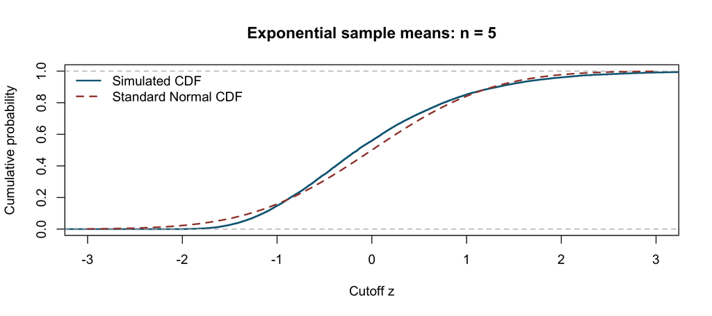

```r
# An empirical CDF returns the fraction at or below each cutoff.
plot(ecdf(z_means), verticals = TRUE, do.points = FALSE,
     xlim = c(-3, 3), ylim = c(0, 1), col = "#176B87", lwd = 2,
     main = "Exponential sample means: n = 5",
     xlab = "Cutoff z", ylab = "Cumulative probability")
curve(pnorm(x), add = TRUE, col = "#A44A3F", lwd = 2, lty = 2)
legend("topleft", c("Simulated CDF", "Standard Normal CDF"),
       col = c("#176B87", "#A44A3F"), lwd = 2, lty = c(1, 2), bty = "n")
```

```r
cdf_comparison <- function(values) {
  cutoffs <- c(-2, -1, 0, 1, 2)
  estimated <- sapply(cutoffs, function(z) mean(values <= z))
  normal <- pnorm(cutoffs)
  data.frame(cutoff = cutoffs, simulated = estimated, normal = normal,
             absolute_gap = abs(estimated - normal))
}
print(cdf_comparison(z_means), digits = 4)
```

```
  cutoff simulated  normal absolute_gap
1     -2    0.0003 0.02275      0.02245
2     -1    0.1479 0.15866      0.01081
3      0    0.5587 0.50000      0.05875
4      1    0.8515 0.84134      0.01016
5      2    0.9603 0.97725      0.01700
```

```r
# A4 supplies the display helpers. Here we inspect what they summarize.
summary_by_n <- data.frame(n = sizes)
summary_by_n$simulated_mean <- sapply(z_by_n, mean)
summary_by_n$simulated_sd <- sapply(z_by_n, sd)
summary_by_n$max_CDF_gap <- sapply(z_by_n, function(values) {
  max(cdf_comparison(values)$absolute_gap)
})
summary_by_n$within_0.02 <- summary_by_n$max_CDF_gap <= .02
print(summary_by_n, digits = 4)
```

```
   n simulated_mean simulated_sd max_CDF_gap within_0.02
1  5      -0.005523       0.9920     0.05875       FALSE
2 20       0.003236       0.9984     0.03035       FALSE
3 40       0.008828       1.0087     0.01740        TRUE
```

```r
# Repeat a case near the cutoff, holding n and B fixed.
recheck_n <- 40
set.seed(100719)
recheck_means <- simulate_means(recheck_n, B)
recheck_z <- (recheck_means - mu) / (sigma / sqrt(recheck_n))
original_z <- z_by_n[[match(recheck_n, sizes)]]
seed_comparison <- rbind(cdf_comparison(original_z), cdf_comparison(recheck_z))
seed_comparison$run <- rep(c("Original", "Different seed"), each = 5)
print(seed_comparison, digits = 4)
```

```
   cutoff simulated  normal absolute_gap            run
1      -2   0.01425 0.02275     0.008500       Original
2      -1   0.15695 0.15866     0.001705       Original
3       0   0.51740 0.50000     0.017400       Original
4       1   0.83805 0.84134     0.003295       Original
5       2   0.96820 0.97725     0.009050       Original
6      -2   0.01370 0.02275     0.009050 Different seed
7      -1   0.15540 0.15866     0.003255 Different seed
8       0   0.52180 0.50000     0.021800 Different seed
9       1   0.83975 0.84134     0.001595 Different seed
10      2   0.96940 0.97725     0.007850 Different seed
```

```r
seed_max_gaps <- c(original = max(cdf_comparison(original_z)$absolute_gap),
                  different_seed = max(cdf_comparison(recheck_z)$absolute_gap))
print(data.frame(run = names(seed_max_gaps), max_CDF_gap = unname(seed_max_gaps),
                 within_0.02 = unname(seed_max_gaps) <= .02), row.names = FALSE)
```

```
            run max_CDF_gap within_0.02
       original      0.0174        TRUE
 different_seed      0.0218       FALSE
```

`lapply()` runs the function once for each element of `sizes`. The function then generates `B` fresh samples of that size. A list can hold each resulting vector separately. `seq_along(sizes)` supplies their positions, so the standardization uses the matching sample size. A4 supplies this scaffolding.

**Discuss:** If a row has a mean near zero and an SD near one, have we established Normality? No. Those moments hold theoretically at every sample size here. The CDF comparison asks a different question about shape.

For A4, all five gaps must be at most 0.02 to count as **close at these checkpoints**. A histogram can still show shape differences. This convention is not a formal Normality test and says nothing about unexamined cutoffs. Report the smallest *tested* qualifying n, rather than a universal cutoff.

There are two sources of difference from `pnorm()`:

- **Normal-approximation error:** the statistic’s actual finite-sample probabilities can differ from those of a Normal distribution.
- **Monte Carlo error:** a finite simulation estimates those actual probabilities imperfectly. Another seed gives another estimate.

Increasing B reduces Monte Carlo noise but leaves the actual sampling distribution unchanged. Changing n changes that distribution and can improve the Normal approximation. A different seed need not change the pass/fail judgment; explain either result. Do not keep changing seeds to obtain a pass.

## 9. A rare-event caution and a poll probability

```r
set.seed(100715)
n <- 30
p <- .02
B <- 20000
counts <- rbinom(B, size = n, prob = p)
print(c(simulated_zero = mean(counts == 0), exact_zero = dbinom(0, n, p)))
```

```
simulated_zero     exact_zero
     0.5446000      0.5454843
```

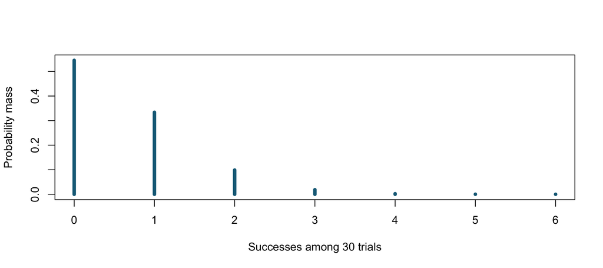

```r
plot(0:6, dbinom(0:6, n, p), type = "h", lwd = 5, col = "#176B87",
     xlab = "Successes among 30 trials", ylab = "Probability mass")
```

```r
# A different example, where a Normal approximation works well:
n <- 400
p <- .6
se <- sqrt(p * (1 - p) / n)
normal_probability <- pnorm(.65, p, se) - pnorm(.55, p, se)
exact_probability <- pbinom(260, n, p) - pbinom(219, n, p)
corrected_probability <- pnorm(260.5, n * p, sqrt(n * p * (1 - p))) -
                         pnorm(219.5, n * p, sqrt(n * p * (1 - p)))
print(c(normal = normal_probability, exact = exact_probability,
        continuity_corrected = corrected_probability))
```

```
              normal                exact continuity_corrected
           0.9587732            0.9637269            0.9635859
```

Sample size 30 has no special guarantee. Here it leaves more than half of the rare-event samples with zero successes. In the poll calculation, the exact event includes counts 220 through 260.

## 10. Squared deviations and the variance distribution

**Predict:** What happens to the typical sum of squares when we add more independent standardized discrepancies?

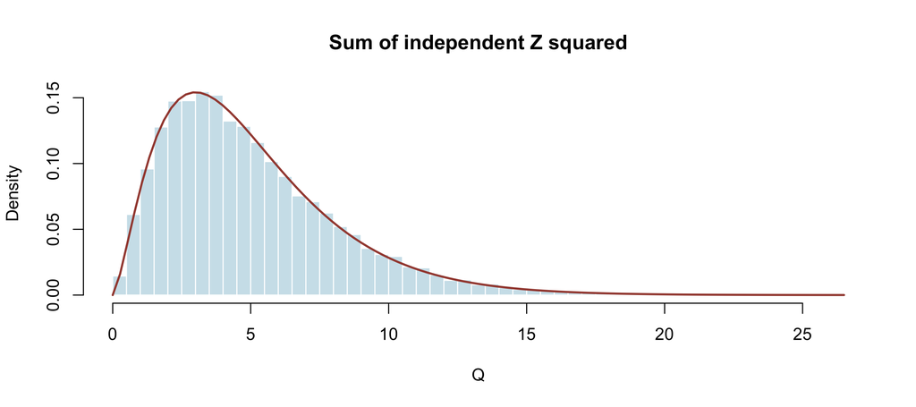

```r
set.seed(100712)
B <- 20000
nu <- 5
q_values <- replicate(B, sum(rnorm(nu)^2))
hist(q_values, breaks = 55, probability = TRUE, col = "#CEE3EB",
     border = "white", main = "Sum of independent Z squared",
     xlab = "Q", ylab = "Density")
curve(dchisq(x, df = nu), add = TRUE, col = "#A44A3F", lwd = 2)
```

```r
print(data.frame(quantity = c("Mean", "Variance"),
                 exact = c(nu, 2 * nu), simulated = c(mean(q_values), var(q_values))))
```

```
  quantity exact simulated
1     Mean     5  5.027143
2 Variance    10 10.026888
```

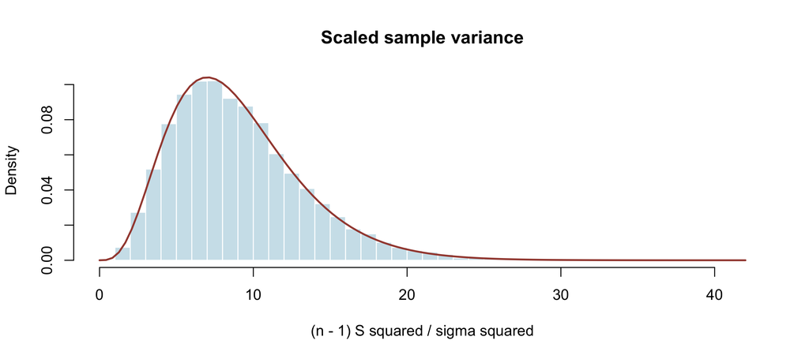

```r
n <- 10
mu <- 12
sigma <- 4
scaled_variances <- replicate(B, {
  sample_x <- rnorm(n, mu, sigma)
  (n - 1) * var(sample_x) / sigma^2
})
hist(scaled_variances, breaks = 55, probability = TRUE, col = "#CEE3EB",
     border = "white", main = "Scaled sample variance",
     xlab = "(n - 1) S squared / sigma squared", ylab = "Density")
curve(dchisq(x, df = n - 1), add = TRUE, col = "#A44A3F", lwd = 2)
```

```r
print(c(simulated_mean = mean(scaled_variances), reference_mean = n - 1))
```

```
simulated_mean reference_mean
       9.05872        9.00000
```

```r
# The residuals sum to zero in a single sample, up to floating-point error.
sample_x <- rnorm(n, mu, sigma)
print(sum(sample_x - mean(sample_x)))
```

```
[1] -2.664535e-15
```

Changing `nu` changes the sum-of-squares distribution. Changing `n` changes the variance statistic’s degrees of freedom. Do not square one shared `Z` five times and call those five independent components. The sample residuals are also dependent, because they sum to zero.

## 11. A random denominator and the actual t statistic

First construct a $t$ variable from independent $Z$ and $Q$. Then generate samples and calculate both z and t statistics.

```r
set.seed(100714)
B <- 20000
nu <- 9
Z <- rnorm(B)
Q <- rchisq(B, df = nu)       # independent of Z
D <- sqrt(Q / nu)
constructed_t <- Z / D
print(c(constructed_variance = var(constructed_t),
        theoretical_variance = nu / (nu - 2)))
```

```
constructed_variance theoretical_variance
            1.262808             1.285714
```

```r
n <- 10
mu <- 12
sigma <- 4
statistics <- replicate(B, {
  sample_x <- rnorm(n, mean = mu, sd = sigma)
  sample_mean <- mean(sample_x)
  sample_sd <- sd(sample_x)
  c(z = (sample_mean - mu) / (sigma / sqrt(n)),
    t = (sample_mean - mu) / (sample_sd / sqrt(n)),
    relative_sd = sample_sd / sigma)
})
# Returning a named vector makes a matrix: one column per repeated sample.
print(dim(statistics))         # Three rows, B columns
```

```
[1]     3 20000
```

```r
print(statistics[, 1:3])       # The first three samples
```

```
                 [,1]     [,2]      [,3]
z           0.2306105 1.592168 0.5131646
t           0.1926206 1.474944 0.7512855
relative_sd 1.1972267 1.079477 0.6830487
```

```r
# statistics["t", ] selects the t row across ALL samples.
print(c(max_identity_error = max(abs(
  statistics["t", ] - statistics["z", ] / statistics["relative_sd", ]))))
```

```
max_identity_error
      8.881784e-16
```

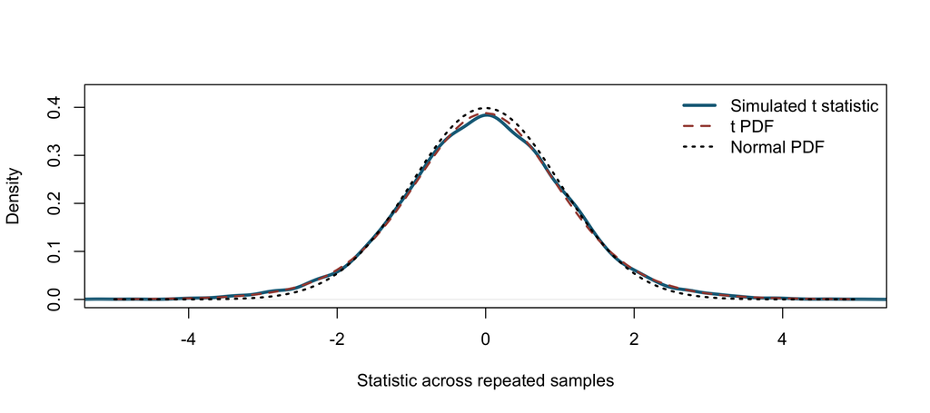

```r
plot(density(statistics["t", ]), xlim = c(-5, 5), ylim = c(0, .43),
     main = "", xlab = "Statistic across repeated samples", ylab = "Density",
     col = "#176B87", lwd = 3)
curve(dt(x, df = n - 1), add = TRUE, col = "#A44A3F", lwd = 2, lty = 2)
curve(dnorm(x), add = TRUE, col = "black", lwd = 2, lty = 3)
legend("topright", c("Simulated t statistic", "t PDF", "Normal PDF"),
       col = c("#176B87", "#A44A3F", "black"), lty = 1:3, lwd = c(3, 2, 2),
       bty = "n")
```

```r
print(data.frame(statistic = c("z", "t"),
                 simulated_tail = c(mean(abs(statistics["z", ]) > 2),
                                    mean(abs(statistics["t", ]) > 2)),
                 theoretical_tail = c(2 * pnorm(-2), 2 * pt(-2, df = n - 1))))
```

```
  statistic simulated_tail theoretical_tail
1         z        0.04400       0.04550026
2         t        0.07485       0.07655282
```

```r
# Symmetry gives the same two-sided tail from either one-sided tail.
print(c(t_lower_doubled = 2 * pt(-2, df = n - 1),
        t_upper_doubled = 2 * pt(2, df = n - 1, lower.tail = FALSE)))
```

```
t_lower_doubled t_upper_doubled
     0.07655282      0.07655282
```

Inside each repetition, the named vector holds several statistics from **one sample**. `replicate()` places those vectors in separate columns. The comma in `statistics["t", ]` separates row and column selections. Leaving the column selection blank retrieves all columns. A4 uses the same structure with rows named `xbar`, `s`, and `t`.

The event $|T|>2$ includes both tails. By symmetry, `2 * pt(-2, df)` and `2 * pt(2, df, lower.tail = FALSE)` agree. The same identity applies to `pnorm()` for a standard Normal variable.

For Normal samples, the sample mean and sample variance are independent, even though we calculate them from the same sample. That special fact connects the construction in the first part to the statistic in the second. Try `n <- 50` in the second part and rerun. Its t curve gets closer to Normal.

The denominator can be above or below its true value. Small estimated SDs sometimes magnify the ratio considerably. A fixed rescaling of a Normal variable would remain Normal and would not reproduce these t tails.

## 12. Optional: F as a ratio of relative variances

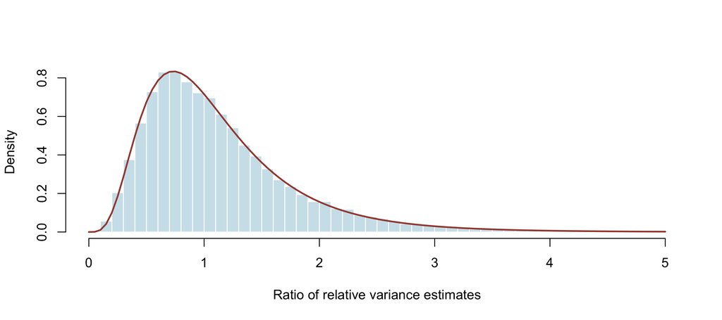

```r
set.seed(100716)
B <- 20000
n1 <- 12
n2 <- 18
f_values <- replicate(B, {
  x <- rnorm(n1, mean = 0, sd = 2)
  y <- rnorm(n2, mean = 3, sd = 5)
  (var(x) / 2^2) / (var(y) / 5^2)
})
hist(f_values, breaks = 70, probability = TRUE, xlim = c(0, 5),
     col = "#CEE3EB", border = "white", main = "",
     xlab = "Ratio of relative variance estimates", ylab = "Density")
curve(df(x, df1 = n1 - 1, df2 = n2 - 1), add = TRUE,
      col = "#A44A3F", lwd = 2)
```

This relationship requires independent samples from Normal populations. When the true variances differ, their ratio must be accounted for. We can postpone testing applications.

## 13. Optional: a centering check for an estimator

This adds only the word **unbiased**: an estimator’s expectation equals the parameter it targets. It does not establish that every realization is close, or that the estimator is best under every criterion.

```r
set.seed(100717)
B <- 20000
n <- 15
mu <- 12
sigma <- 4
sample_means <- replicate(B, mean(rnorm(n, mu, sigma)))
print(c(target = mu, average_of_estimates = mean(sample_means),
        simulated_spread = sd(sample_means), exact_se = sigma / sqrt(n)))
```

```
              target average_of_estimates     simulated_spread
           12.000000            12.003806             1.035867
            exact_se
            1.032796
```

Estimator comparisons and the bias-variance tradeoff will follow later.

## References

Speegle and Clair, [PSD Chapter 5](https://probstatsdata.com/SimulationRV.html), especially Sections 5.3-5.5. R Core Team, [`density()`](https://stat.ethz.ch/R-manual/R-devel/library/stats/html/density.html) and the installed R help for `hist`, `replicate`, `Chisquare`, and `TDist`. The polling illustration adapts Brad LeVeck’s earlier seminar notes.